# jekyll-jupyter-notebook20251115-3203-8227ny

**语义鸿沟** ： 计算机无法从图像中直接提取出信息

### 近邻分类器

- 近邻分类器：在训练数据种匹配最接近的数据标签
- 衡量距离的方式
  - L1 距离：$d_1(I_1,I_2)=\sum_p|I_1^p-I_2^p|$
  - L2 距离: $d_2(I_1,I_2)=\sqrt{\sum_p\left(I_1^p-I_2^p\right)^2}$

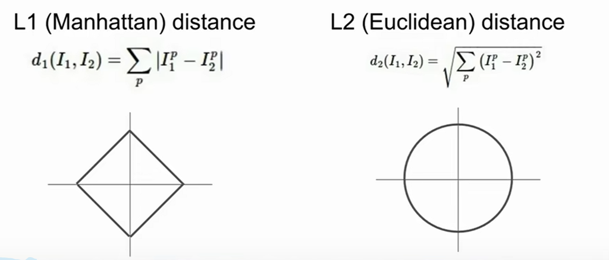

改进：k-近邻分类器，使用最近的k个训练集数据标签进行投票，使决策边界平滑，使模型获得更高的鲁棒性

**超参数**：模型无法通过学习得到的参数，需要在训练之前提前设定

**交叉验证**：

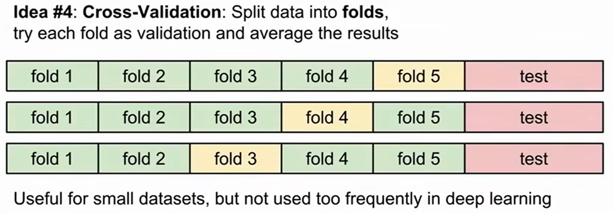

近邻分类器上的问题：

- 无法很好的用于图像分类因为距离的概念很难描述图像之间的差距
- 维度灾难：在高维度下距离的概念失效；需求训练集数量剧增

### 线性分类器

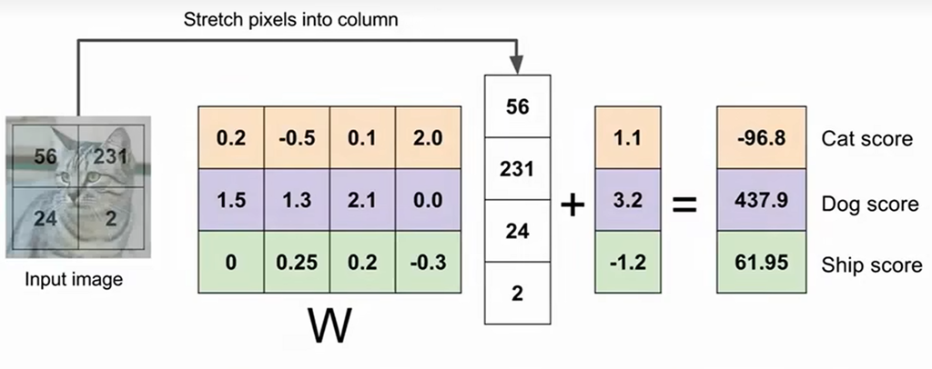

- 每个线性分类器可以学习到一个类的模板（模板匹配的过程），通过逆推我们可以看到其学习到的图像 **线性分类器的问题**：
  - 无法解决一些通过一条线性划分无法解决的问题

### 损失函数

在线性模型中，我们为了可以找到最佳的`W`,我们需要找到一个评价当前W的函数，损失函数便可以衡量W的好坏程度。

$$ L=\frac{1}{N}\sum_{i}L_{i}(f(x_{i},W),y_{i}) $$

$L_i$是衡量某一组数据和标签之间的差距（即损失）

#### `SVM loss` :

$$L_i=\sum_{j\neq y_i}\max(0,s_j-s_{y_i}+\Delta)$$

我们通过一个固定的$\Delta$（边际）来对损失进行规范，其取值是无关紧要的。真实类别得分必须比其他类别得分至少高 $\Delta$，否则会产生损失

对于某一个图像得到的分数不高于其对应正确类别的分数。

因此，多分类 SVM 的核心思想是：让 “真实类别 $y_i$ 的得分 $s_{y_i}$”，比 “所有其他类别 $j$ 的得分 $s_j$” 至少大 $\Delta$。

- 超参数$\Delta$的影响
  - $\Delta$ 越大，模型需要学习的 “类别区分度” 越高（真实类别得分必须远高于其他类别），可能更鲁棒，但也可能更难训练（易欠拟合）。
  - 通常设为 $\Delta=1$（经验值），也可根据任务调整（如数据集类别重叠严重时，可减小 $\Delta$）。

若使用SVM损失函数进行训练，一开始随机生成的`W`应该会使所有分类的score接近于一个平均值，因此在一开始的损失函数计算值应该接近于 $c-1$ (`c` 为分类数)。我们也可以用这个特性进行Debug（$\Delta = 1$时）

```
# 矢量化后的SVM损失函数计算
def L_i_vectorized(x,y,W):
    scores = W.dot(x)
    margins = np.maximum(0,scores-scores[y]+1)
    margins[y] = 0
    loss_i = np.sum(margins)
    return loss_i
```

#### `softmax Loss`:

使用`softmax`函数将原本的得分转化为概率分布 $${P(Y=k|X=x_{i})=\frac{e^{s_{k}}}{\sum_{j}e^{s_{j}}}}$$ $${L_i=-\log P(Y=y_i|X=x_i)}$$ $$\text{in summary:}\quad L_i=-\log(\frac{e^{sy_i}}{\sum_je^{s_j}})$$

同理，若使用softmax进行训练时，随机生成的W应该使一开始的损失函数接近于 $\log{C}$

#### `softmax`和`SVM`的对比

[figure not shown]

- Softmax 关注 “真实类别概率尽可能大”（通过交叉熵损失），但不限制 “其他类别得分的绝对大小”
- 多分类 SVM 关注 “真实类别与其他类别得分的相对间隔”，只要间隔满足 $\Delta$，不关心概率的绝对高低

### 正则化（Regularization）

为了防止模型在训练时过拟合，我们需要引入一些项来惩罚模型的复杂参数

$$L(W)=\frac{1}{N}\sum_{i=1}^NL_i(f(x_i,W),y_i)+\lambda R(W)$$

最终在衡量这一次的训练结果时，我们会使用损失函数在所有训练集上的平均值，即：$$L=\frac{1}{N}\sum_{i=1}^NL_i$$

### 优化（Optimization）

传统的梯度下降算法：

```
while True:
    weigths_grad = evaluate_gradient(loss_fun,data,weights)
    weigths += - step_size * weights_grad
```

小批量随机梯度下降(SGD):

- 采样：从训练集选一小批数据，模拟整体数据的分布。
- 计算梯度：用这批数据计算损失函数对参数的梯度（反映当前参数下，损失的变化趋势）。
- 更新参数：沿梯度反方向调整参数，减小损失。
- 循环：重复上述步骤，让参数逐渐逼近 “损失最小” 的最优解。

```
while True:
    data_batch = sample_training_data(data,256)
    weights_grad = evaluate_gradient(loss_fun, data_batch, weights)
    weights += - step_size * weights_grad  # perform parameter update
```